# Organising Your Code

Data Science Workflows

Dr Zak Varty

## Outline

Directories >> Files >> Contents

- Focus specifically on code
  - High level approaches to coding
  - Naming conventions
  - Style guides
  - Useful packages

# 1. Functional and Object Oriented Programming

## Functional Programming

A functional programming style has two major properties:

- Object immutability,
- Complex programs written using function composition.

Mathematicians often find this way of operating quite intuitive:

$$y = g(x) = f_3 \circ f_2 \circ f_1(x).$$

## The Pipe Operator

Function composition gets messy at ~3 functions

The `{magrittr}` pipe operator facilitates this compositional style: `%>%`

Recent addition of base R pipe `|>` (R >= 4.1), mostly behaves the same.

```r
log(exp(cos(sin(pi))))
```

```r
library(magrittr)
pi %>%
  sin() %>%
  cos() %>%
  exp() %>%
  log()
```

```r
iris |>
  head(n = 3)
```

## When not to pipe !%>%

Avoid using the pipe when:

- Manipulating more than one object at a time. (Pipes are for a sequence of steps applied to a single primary object.)
- There are meaningful intermediate objects that could be given informative names.

[figure not shown]

## Object Oriented Programming

The alternative to functional programming is object oriented programming.

- Solve problems by using lots of simple objects
- R has 3 OOP systems: S3, S4 and R6.
- Objects belong to a class, have methods and fields.
- Agent based simulation of beehive.

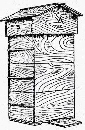

# 2. Structuring R scripts

## Top of the Script

- Start script with a comment of 1-2 sentences explaining what it does.
- `setwd()` and `rm(ls())` are the devil’s work.
  - “Session” > “Restart R” or Keyboard shortcut: crtl/cmd + shift + 0
- Polite to gather all `library()` and `source()` calls.
- Rude to mess with other people’s set up using `install.packages()`.
- Portable scripts use paths relative to the root directory of the project.

## Portable file paths with `{here}`

```r
# Bad - breaks if project moved
source("zaks-mbp/Desktop/exciting-new-project/src/helper_functions/rolling_mean.R")

# Better - breaks if Windows
source("../../src/helper_functions/rolling_mean.R")

# Best - but use here:here() to check root directory correctly identified
source(here::here("src","helper_functions","rolling_mean.R"))

# For more info on the here package:
vignette("here")
```

For even more on `{here}`, try: [r-wtf chapter](https://rstats.wtf/project-oriented-workflow.html), [r4ds chapter](https://r4ds.had.co.nz/workflow-projects.html) or [project oriented workflow blog post](https://www.tidyverse.org/blog/2017/12/workflow-vs-script/).

# 3. Style Gudie Summary

## The Body of the Code - Comments

Well commented and organised code easier to read and understand.

```r
# This is an example script showing good use of comments and sectioning

library(here)
source(here("src","helper_functions","rolling_mean.R"))

#===============================================================================  <- 80 characters max for readability
# Major Section on Comments ----
#===============================================================================

#-------------------------------------------------------------------------------
##  Minor Section on inline comments ----
#-------------------------------------------------------------------------------
x <- 1:10 # this is an inline comment

#-------------------------------------------------------------------------------
##  Minor Section on full line comments ----
#-------------------------------------------------------------------------------
rolling_mean(x)
# This is an full line comment
```

## Naming Things Revisited: Objects = Nouns

Object names should use only lowercase letters, numbers, and `_`.

Use underscores (`_`) to separate words within a name. (`snake_case`)

Use singular over plural names.

```r
# Good
day_one
day_1

# Bad
first_day_of_the_month
DayOne
dayone
djm1
```

## Naming Things Revisited: Functions = Verbs

Function names should use only lowercase letters, numbers, and `_`.

Use underscores (`_`) to separate words within a name. (`snake_case`)

Suggest imperative mood, as in a recipe.

Break long functions over multiple lines. 4 vs 2 spaces.

```r
# Good
add_row()
permute()

# Bad
row_adder()
permutation()

long_function_name <- function(
    a = "a long argument",
    b = "another argument",
    c = "another long argument") {
  # As usual code is indented by two spaces.
}
```

## Casing Consistently

Many options for separating words within names:

- `CamelCase`
- `pascalCase`
- `snakecase`
- `underscore_separated` ❤️
- `hyphen-separated`
- `point.separated` 💀

## Style guide in brief

1. Use comments to structure your code
2. Objects = Nouns
3. Functions = Verbs
4. Use snake case and friendly grammar

## Further tips for friendly coding

- Write your code to be easily understood by humans.
- Use informative names, typing is cheap.

```r
# Bad
for(i in dmt){
  print(i)
}

# Good
for(temperature in daily_max_temperature){
  print(temperature)
}
```

- Divide your work into logical stages, human memory is expensive.

# Tidyverse Style Guide

For further details on writing clean, readable code see the [Tidyverse Style Guide](https://style.tidyverse.org/).

# 4. Reduce, Reuse, Recylce

## Writing reusable code (DRY coding)

- **If you do something twice, write a function.**
  - when you write a function, document it.
  - when you write a function, test it.
- **If your function is used in two scripts, it gets it’s own script.**
  - name that script after the function & save it in the `src/` directory of your project
- **If your function is used across projects, add it to a package.**

## Remembering how to use your own code

*When you write a function, document it.* What should the documentation contain?

- Inputs
- Outputs
- Example use cases
- Author (if not obvious or working in a team)

## Roxygen for code documentation

The R package `{Roxygen}` can help with this.

1. `install.packages("Roxygen")`
2. With cursor inside function: Code > Insert Roxygen Skeleton
3. Keyboard shortcut: *cmd + option + shift + r* or *crtl + option + shift + r*
4. Fill out relevant fields

## Roxygen Example

```r
#' Title
#'
#' @param x
#' @param remove_NA
#'
#' @return
#' @export
#'
#' @examples
geometric_mean <- function(x, remove_NA = FALSE){
  # Function body goes here
}
```

## Roxygen Example

```r
#' Calculate the geometric mean of a numeric vector
#'
#' @param x numeric vector
#' @param remove_NA logical scalar, indicating whether NA values should be stripped before computation proceeds.
#'
#' @return the geometric mean of the values in `x`, a numeric scalar value.
#'
#' @examples
#' geometric_mean(x = 1:10)
#' geometric_mean(x = c(1:10, NA), remove_NA = TRUE)
#'
geometric_mean <- function(x, remove_NA = FALSE){
  # Function body goes here
}
```

For more on Roxygen, see the [package documentation](https://roxygen2.r-lib.org/) or the chapter of R packages on [function documentation](https://r-pkgs.org/man.html).

## Checking Your Code

*If you write a function, test it.* Testing code has two main purposes:

- To warn or prevent user misuse (e.g. strange inputs),
- To catch edge cases.

Testing is fun but painful - you are trying as hard as you can to break your beautiful new creation!

## An Informal Testing Workflow

1. Write a function
2. Experiment with the function in the console, try to break it
3. Fix the break and repeat.

**Problems:** Time consuming and not reproducible.

## Formalising Our Testing Workflow

- Test in a script, named after the function and stored in the `tests/` directory.
- The R package `{testthat}` provides useful functions for unit testing your code. Check out the [{testthat} function reference](https://testthat.r-lib.org/reference/index.html) for more examples.
- We’ll explore this in more detail during the live session.

```r
testthat::expect_equal(
  object = geometric_mean(x = c(1, NA), remove_NA = FALSE),
  expected = NA)

# Error: geometric_mean(x = c(1, NA), remove_NA = FALSE) not equal to NA.
# Types not compatible: double is not logical
```

## Summary

- Functional and Object Oriented Programming
- Structuring your scripts
- Styling your code
- Reduce, reuse, recycle
- Documenting and testing

Effective Data Science: Workflows - Organising Your Code - Zak Varty